# CIS242_HW6_Shuyue_Yang

##### CIS 242

## Spring 2022

## HOMEWORK ASSIGNMENT 6

Please compile your responses use markdown in your Jupyter notebook to answer the questions. If you prefer, you may also submit a Word or PDF document with the responses along the PDF or HTML version of the completed notebook.

#### Active notebooks (.ipynb files) or raw code (.py files) will NOT be accepted and no points will be given.

The code part of the files will not be graded, but they will be checked if necessary to verify your findings and recommendations. Point deductions may occur if there are major discrepancies between your written answers and the output from the code.

#### Please make sure that your answers are readable and don't run off the page when the notebook is converted to HTML or PDF.

Questions are worth 2 points each for a total of **26 points**. This assignment is due at **MIDNIGHT on April 7.** Assignments turned in before midnight on April 12 will be considered for 50% credit. **No assignments will be accepted after April 12.**

## Working with movie reviews

You have been hired by a new streaming service to try to decide which movies they should bid for to get exclusive rights before Netflix gets them. You have access to user reviews from the test screenings that the studios do.

There are positive and negative reviews for each movie. You want to be able to predict the rating of a movie based on user reviews so you can help your new company know how to predict "good" movies based on review terms. You have a data file movie_reviews.csv to work with.

#### 1. Read in the reviews and do some EDA. What can you say about the data? Create an unconstrained vector space. How many features do you have?

```python
The dataset has 25000 observations (moview reviews) and 3 attributes (movie ID, rating, review content)
The mean rating of the moview reviews is 5.51296 out of 10.
There are 5022 reviews have rated the movies 1 out of 10, 4999 reviews have rated the movies 10 out of 10,
          2850 reviews have rated the movies 8 out of 10, 2635 reviews have rated the movies 4 out of 10,
          2541 reviews have rated the movies 3 out of 10, 2344 reviews have rated the movies 9 out of 10,
          2307 reviews have rated the movies 7 out of 10, 2302 reviews have rated the movies 2 out of 10,
          and no reviews have rated the movies 5 or 6 out of 10.
I get 74899 features.
```

```python
# EDA

df = pd.read_csv('C:/Users/Akira Yang/Desktop/2022Spring/CIS 242/HW6/movie_reviews.csv', sep=",", header=0, names=['Movie ID','Rating','Review'])
print("Input data has {} rows and {} columns".format(len(df), len(df.columns)))
print(df.head())
```

```
Input data has 25000 rows and 3 columns
   Movie ID  Rating                                             Review
0      1821       4  Alan Rickman & Emma Thompson give  performance...
1      9487       1  I have seen this movie and I did not care for ...
2      4604       4  In Los Angeles, the alcoholic and lazy Hank Ch...
3      2828       2  This film is bundled along with "Gli fumavano ...
4     10890       1  I only comment on really very  films and on ut...
```

```
           Movie ID        Rating
count  25000.000000  25000.000000
mean    6249.500000      5.512960
std     3608.511342      3.490902
min        0.000000      1.000000
25%     3124.750000      2.000000
50%     6249.500000      5.500000
75%     9374.250000      9.000000
max    12499.000000     10.000000
```

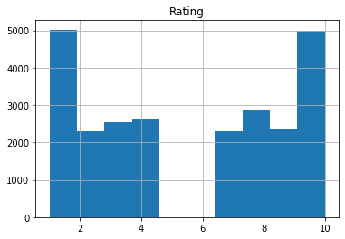

```
1     5022
10    4999
8     2850
4     2635
3     2541
9     2344
7     2307
2     2302
Name: Rating, dtype: int64
```

```python
print(df.describe())
df.hist(column = 'Rating')
plt.show()
print(df['Rating'].value_counts())
```

```python
bow = CountVectorizer(binary = False) #define the transformation
bow_movie = bow.fit_transform(df['Review']) #apply the transformation
print(bow_movie.shape)
```

```
(25000, 74899)
```

#### 2. What are the top 20 words in the feature space? Are you surprised by this? Why or why not?

```python
The top 20 words are "the, and, of, to, is, it, in, this, that, was, as, movie, with, for, but, film, you, on, not, are".
I am not surprised by this result.
Those words are mostly stopwords in English and are common to be seen in sentences.
We have not set any restrictions on the vectorizer, so it is understandable that they are the top 20 words in the feature space.
```

```python
names = bow.get_feature_names_out()
count = np.sum(bow_movie.toarray(),axis = 0)
count_df = pd.DataFrame(count.tolist(),index = names,columns = ['count'])
count_df.sort_values(['count'],ascending = False).head(20)
```

|  | count |
| --- | --- |
| the | 330651 |
| and | 159989 |
| of | 143294 |
| to | 132191 |
| is | 103575 |
| it | 94236 |
| in | 92646 |
| this | 74884 |
| that | 70462 |
| was | 47353 |
| as | 44720 |
| movie | 43880 |
| with | 43153 |
| for | 43040 |
| but | 40877 |
| film | 39477 |
| you | 34816 |
| on | 33811 |
| not | 30075 |
| are | 28917 |

#### 3. Create a feature space that removes stopwords. What is the size of the space now? What are the top words? Is this an improvement in size or content? Why or why not?

```python
After removing the stopwords, we now have 74588 features.
The top 20 words are "movie,film,like,just,time,really,story,people,don,make,movies,way,characters,think,watch,films,character,seen,love,plot".
The common words in English have been excluded, and the size of the feature space is reduced on some scale (reduced from 74899 to 74588).
This is an improvement in both size and content, but it does not help much.
We need to further put some limits on how many reviews the terms can be found in.
```

```python
# remove stopwords

stopw = CountVectorizer(binary = False, stop_words = 'english')
stopw_movie = stopw.fit_transform(df['Review'])
print(stopw_movie.shape)
```

```
(25000, 74588)
```

```python
names = stopw.get_feature_names_out()
count = np.sum(stopw_movie.toarray(),axis = 0)
count_df = pd.DataFrame(count.tolist(),index = names,columns = ['count'])
count_df.sort_values(['count'],ascending = False).head(20)
```

|  | count |
| --- | --- |
| movie | 43880 |
| film | 39477 |
| like | 19869 |
| just | 17387 |
| time | 12364 |
| really | 11346 |
| story | 11103 |
| people | 8891 |
| don | 8769 |
| make | 7851 |
| movies | 7630 |
| way | 7600 |
| characters | 7282 |
| think | 7037 |
| watch | 6968 |
| films | 6856 |
| character | 6850 |
| seen | 6687 |
| love | 6547 |
| plot | 6388 |

#### 4. Create a feature space that requires a minimum frequency for a term as well as removing stopwords. What limit will you choose? Why? What is the effect on the feature space?

```python
I choose to set a minimum frequency at 0.1 that requires a term to appear in at least 10% of the reviews.
The feature space is largely reduced from 74588 to 71 features,
which is a manageable size for further investigation.
```

```python
# change parameter (set a minimum frequency)

stopmin = CountVectorizer(binary = False, min_df = 0.1, stop_words = 'english')
stopmin_movie = stopmin.fit_transform(df['Review'])
print(stopmin_movie.shape)
print(stopmin.get_feature_names_out())
```

```
(25000, 71)
['10' 'acting' 'actors' 'actually' 'better' 'big' 'cast' 'character'
 'characters' 'come' 'did' 'didn' 'director' 'does' 'doesn' 'don' 'end'
 'fact' 'far' 'film' 'films' 'funny' 'gets' 'going' 'got' 'interesting'
 'isn' 'just' 'know' 'life' 'like' 'little' 'long' 'look' 'lot' 'love'
 'make' 'makes' 'man' 'movie' 'movies' 'new' 'old' 'people' 'plot'
 'pretty' 'quite' 'real' 'really' 'right' 'saw' 'say' 'scene' 'scenes'
 'seen' 'story' 'thing' 'things' 'think' 'thought' 'time' 'times' 've'
 'want' 'watch' 'watching' 'way' 'work' 'world' 'years' 'young']
```

#### 5. Investigate this feature space. What tokens would you like to remove that remain? Why? (Or Why not?)

```python
Number "10" can be removed as it does not have textual meaning.
"ve" can be removed as it should be part of the common words "I've" and does not reflect whether the rating is good or not.
I would also like to remove "film, films, movie, movies"
since they are absolutely the most common words that will appear in movie reviews
but will not be beneficial to predict the rating of a movie.
```

#### 6. Create custom stopword list to remove the tokens. How does this affect your feature space? If choose not to remove any more tokens, explain why your feature space is appropriate as is - be specific.

```python
After creating and removing my custom stopwords, the feature space is reduced from 71 to 65 features.
However, we have not used stemming to combine the counts of each stem word within different versions.
For example, 'scene & scenes', 'character & characters' can be counted together.
```

```python
# create custom stopword list and remove

skl_stopwords = list(text.ENGLISH_STOP_WORDS)
my_stopwords = skl_stopwords + ["10","ve","film", "films", "movie", "movies"]

stopmin = CountVectorizer(binary = False, min_df = 0.1, stop_words = my_stopwords)
stopmin_movie = stopmin.fit_transform(df['Review'])
print(stopmin_movie.shape)
print(stopmin.get_feature_names_out())
```

```
(25000, 65)
['acting' 'actors' 'actually' 'better' 'big' 'cast' 'character'
 'characters' 'come' 'did' 'didn' 'director' 'does' 'doesn' 'don' 'end'
 'fact' 'far' 'funny' 'gets' 'going' 'got' 'interesting' 'isn' 'just'
 'know' 'life' 'like' 'little' 'long' 'look' 'lot' 'love' 'make' 'makes'
 'man' 'new' 'old' 'people' 'plot' 'pretty' 'quite' 'real' 'really'
 'right' 'saw' 'say' 'scene' 'scenes' 'seen' 'story' 'thing' 'things'
 'think' 'thought' 'time' 'times' 'want' 'watch' 'watching' 'way' 'work'
 'world' 'years' 'young']
```

#### 7. Investigate the feature space further. What other changes you would like to make? Why? Choose custom dictionary replacement or stemming and implement your choice. How does that affect your feature space now?

```python
I first use the Snowball Stemmer to reduce words to their most common stem.
Through Snowball Stemmer, I successfully get stem words such as "character", "scene",
but the feature space increases to 92 with the addition of stem words.

Thus, I make the custom dictionary replacement as well.
Through my custom dictionary replacement, I successfully get the stem words and reduce the size of the feature space to 58.
```

```python
# Snowball Stemmer

df['sstem'] = df['Review'].apply(lambda x: [ss.stem(y) for y in x.split()])
df['sstem'] = [" ".join(token) for token in df['sstem']]
```

```python
ss = CountVectorizer(binary = False, min_df = 0.1, stop_words = my_stopwords)
ss_dm = ss.fit_transform(df['sstem'])
print(ss_dm.shape)
print(ss.get_feature_names_out())
```

```
(25000, 92)
['act' 'actor' 'actual' 'ani' 'anoth' 'becaus' 'befor' 'believ' 'better'
 'big' 'bit' 'cast' 'charact' 'come' 'day' 'did' 'didn' 'direct'
 'director' 'doe' 'doesn' 'don' 'end' 'enjoy' 'everi' 'fact' 'far' 'feel'
 'got' 'guy' 'hard' 'high' 'isn' 'just' 'know' 'life' 'like' 'littl'
 'live' 'long' 'look' 'lot' 'love' 'make' 'man' 'mani' 'movi' 'music'
 'need' 'new' 'noth' 'old' 'onli' 'peopl' 'perform' 'play' 'plot' 'point'
 'pretti' 'quit' 'real' 'realli' 'right' 'role' 'saw' 'say' 'scene'
 'script' 'seen' 'set' 'someth' 'star' 'start' 'stori' 'sure' 'th' 'thing'
 'think' 'thought' 'time' 'tri' 'turn' 'use' 'veri' 'want' 'watch' 'way'
 'whi' 'work' 'world' 'year' 'young']
```

```python
# custom dictionary replacement

movie_dict = {"characters":"character","makes":"make","scenes":"scene",
              "things":"thing","think":"thought","times":"time","watching":"watch"}

def multiple_replace(dict,text):
    text = str(text).lower()
    regex = re.compile("(%s)"%"|".join(map(re.escape,dict.keys())))
    return regex.sub(lambda mo: dict[mo.string[mo.start():mo.end()]],text)

df['cleantext'] = df.Review.apply(lambda x: multiple_replace(movie_dict,x))

stopmin = CountVectorizer(binary = False, min_df = 0.1, stop_words = my_stopwords)
stopmin_movie = stopmin.fit_transform(df['cleantext'])
print(stopmin_movie.shape)
print(stopmin.get_feature_names_out())
```

```
(25000, 58)
['acting' 'actors' 'actually' 'better' 'big' 'cast' 'character' 'come'
 'did' 'didn' 'director' 'does' 'doesn' 'don' 'end' 'fact' 'far' 'funny'
 'gets' 'going' 'got' 'interesting' 'isn' 'just' 'know' 'life' 'like'
 'little' 'long' 'look' 'lot' 'love' 'make' 'man' 'new' 'old' 'people'
 'plot' 'pretty' 'quite' 'real' 'really' 'right' 'saw' 'say' 'scene'
 'seen' 'story' 'thing' 'thought' 'time' 'want' 'watch' 'way' 'work'
 'world' 'years' 'young']
```

#### 8. Choose the feature space you think most appropriate to use in a model. Now we want to use this predict the audience feeling for a movie. How will you do that? What target variable will help decide which movies to buy? How will you impliment this?

```python
I think the most appropriate feature space to use in a model
is the one using my custom dictionary replacement and my custom stopwords removed, with a minimum frequency of 0.1.
It has a manageable size of 58 features and has reduced feature words to their most common stem.
The target variable is the rating of each movie review.
But instead of using the original rating data which has a 1 to 10 scale and requires a multi-class classification,
I recategorize those data into a 2-class classification.
For those within the 1 to 4 scale, they are "negative" rating,
and for those within the 7 to 10 scale, they are "positive rating."
```

```python
df['Rating'].replace([1,2,3,4],'negative',inplace = True)
df['Rating'].replace([7,8,9,10],'positive',inplace = True)
print(df.head())
```

```
   Movie ID    Rating                                             Review  \
0      1821  negative  Alan Rickman & Emma Thompson give  performance...
1      9487  negative  I have seen this movie and I did not care for ...
2      4604  negative  In Los Angeles, the alcoholic and lazy Hank Ch...
3      2828  negative  This film is bundled along with "Gli fumavano ...
4     10890  negative  I only comment on really very  films and on ut...

                                               sstem  \
0  alan rickman & emma thompson give perform with...
1  i have seen this movi and i did not care for t...
2  in los angeles, the alcohol and lazi hank chin...
3  this film is bundl along with "gli fumavano le...
4  i onli comment on realli veri film and on utte...

                                           cleantext
0  alan rickman & emma thompson give  performance...
1  i have seen this movie and i did not care for ...
2  in los angeles, the alcoholic and lazy hank ch...
3  this film is bundled along with "gli fumavano ...
4  i only comment on really very  films and on ut...
```